# SwiftKey - Exploratory Data Analysis

Stefano Masneri

3 September 2016

# Introduction

## Setup

The first thing to do is to load the necessary libraries and set a seed for random number generation, in order to guarantee reproducibility of the results

```r
library(NLP)
library(tm)
library(SnowballC)
library(ggplot2)
library(wordcloud)
library(stringi)
library(slam)
set.seed(20160903)
```

Then, we load our dataset. We assume that the data has already been downloaded and unzipped

```r
dirname = "/Users/stefano/CourseraSwiftKey/en_US/"
blogFile <- paste0(dirname, 'en_US.blogs.txt')
newsFile <- paste0(dirname, 'en_US.news.txt')
twitFile <- paste0(dirname, 'en_US.twitter.txt')
blog <- readLines(blogFile, encoding = 'UTF-8', skipNul = TRUE)
news <- readLines(newsFile, encoding = 'UTF-8', skipNul = TRUE)
twit <- readLines(twitFile, encoding = 'UTF-8', skipNul = TRUE)
```

To avoid problems during the next steps of the analysis, we remove all non-english characters from the dataset. More thorough analyses could, for example, check the number of words containing foreign characters to estimate the amount of words from other languages. For simplicity, though, we will just remove these characters.

```r
blog <- iconv(blog, "latin1", "ASCII", sub="")
news <- iconv(news, "latin1", "ASCII", sub="")
twit <- iconv(twit, "latin1", "ASCII", sub="")
allData = list(blog, news, twit)
```

## Get basic info about the data

Once the data has been loaded in memory, we extract basic info such as the number of lines and the distribution of words per line. This way we can have an idea of how similiar (or different) our three text files are

```r
filenames = c(basename(blogFile), basename(newsFile), basename(twitFile))
sizes = c(file.info(blogFile)$size, file.info(newsFile)$size, file.info(twitFile)$size ) / (1024*1024)
numLines = (sapply(allData, length))
numWords = (sapply(allData, stri_stats_latex)['Words',])
wordFreq = t(sapply(allData, function(x) summary(stri_count_words(x))[c('Min.', 'Mean', 'Max.')]))
colnames(wordFreq) = c('Min_words', 'Avg_words', 'Max_words')

fileInfo <- data.frame(
  'name' = filenames,
  'size_MBytes' = sizes,
  'Num_lines' = numLines,
  'Num_words' = numWords,
  wordFreq
)
fileInfo
```

```
##                name size_MBytes Num_lines Num_words Min_words Avg_words
## 1   en_US.blogs.txt    200.4242    899288  37191870         0     41.71
## 2    en_US.news.txt    196.2775   1010242  34391024         0     34.40
## 3 en_US.twitter.txt    159.3641   2360148  30437090         1     12.75
##   Max_words
## 1      6725
## 2      1796
## 3        47
```

## Sampling the data

To keep the processing time shorter durin this exploratory step, we decided to sample the dataset. We randomly extract 5% of all the lines in the three dataset using a binomial process. If we were going to create a prediction model discarding 95% of the data wouldn’t have made sense, but for a quick exploration of our corpus and get a feeling of the more common words, bigrams and trigrams it is indeed a sensible idea.

```r
samplingFrac <- 0.05
subsetBlog <- blog[1 == rbinom(length(blog), 1, samplingFrac)]
subsetNews <- news[1 == rbinom(length(news), 1, samplingFrac)]
subsetTwit <- twit[1 == rbinom(length(twit), 1, samplingFrac)]
subsetAllData <- c(subsetBlog, subsetNews, subsetTwit)
#CREATE THE CORPUS
docs <- Corpus(VectorSource(subsetAllData))
```

## Preprocessing

We prepare our text for analyses by performing some common tasks, such as removing numbers and punctuation, or setting all the text to lowercase. More refined preprocessing could also remove special characters like "*@*" and “*#*” which are used a lot in tweets.

```r
# remove punctuation
docs <- tm_map(docs, removePunctuation)
#remove numbers
docs <- tm_map(docs, removeNumbers)
#convert to lowercase
docs <- tm_map(docs, tolower)
#remove stopwords
docs <- tm_map(docs, removeWords, stopwords("english"))
#strip whitespace
docs <- tm_map(docs, stripWhitespace)
#treat as text
docs <- tm_map(docs, PlainTextDocument)
```

## Calculate Frequencies

After the preprocessing steps we are finally ready to compute the word frequencies inside our corpus. We will compute the frequencies of single words as well as bigrams and trigrams.

```r
dtm_unigram <- DocumentTermMatrix(docs)
#tdm_unigram <- TermDocumentMatrix(docs)
# do the same for 2-gram and 3-gram
BigramTokenizer <- function(x) unlist(lapply(ngrams(words(x), 2), paste, collapse = " "), use.names = FALSE)
TrigramTokenizer <- function(x) unlist(lapply(ngrams(words(x), 3), paste, collapse = " "), use.names = FALSE)
#tdm_bigram <- TermDocumentMatrix(docs, control = list(tokenize = BigramTokenizer))
#tdm_trigram <- TermDocumentMatrix(docs, control = list(tokenize = TrigramTokenizer))
dtm_bigram <- DocumentTermMatrix(docs, control = list(tokenize = BigramTokenizer))
dtm_trigram <- DocumentTermMatrix(docs, control = list(tokenize = TrigramTokenizer))
```

## Analyze single word frequencies

We can now inspect for example the 10 words appearing most and least often

```r
freq <- col_sums(dtm_unigram)
length(freq)
```

```
## [1] 141891
```

```r
ord <- order(freq)
freq[head(ord, 10)]
```

```
##                                          aaaaaaaaaahhhhhhh
##                                                          1
## aaaaaaaaaiwwwwwwwwwwwwwwwwwwwwwwwwwwwwwwwwwwwwwwwwwwwwwwll
##                                                          1
##                                             aaaaaaannnnddd
##                                                          1
##                                               aaaaaahhhhhh
##                                                          1
##                                                   aaaaaand
##                                                          1
##                                                aaaaahhhhhh
##                                                          1
##                                                   aaaaaint
##                                                          1
##                                                   aaaaalll
##                                                          1
##                                                    aaaaand
##                                                          1
##                                                    aaaaare
##                                                          1
```

```r
freq[tail(ord, 10)]
```

```
##  dont   new  time   get   can  like   one  just  said  will
##  8872  9648 10773 11235 12404 13289 14414 15201 15575 16135
```

We see that the 10 least common words appear just once. Since it is very likely that a lot of words appear just once in the corpus, it may be interesting to check the distribution of the frequencies, that is how many words appear just once, twice and so on

```r
head(table(freq), 10)
```

```
## freq
##     1     2     3     4     5     6     7     8     9    10
## 80617 16450  8032  5012  3510  2690  2163  1678  1429  1172
```

```r
tail(table(freq), 10)
```

```
## freq
##  8872  9648 10773 11235 12404 13289 14414 15201 15575 16135
##     1     1     1     1     1     1     1     1     1     1
```

Here we can see that more than 80000 terms appear just once and more than 16000 words appear just twice. At the other end of the spectrum we see a lot of single words appearing thouseands of times. We can also plot the words that appear at least 5000 times in the corpus

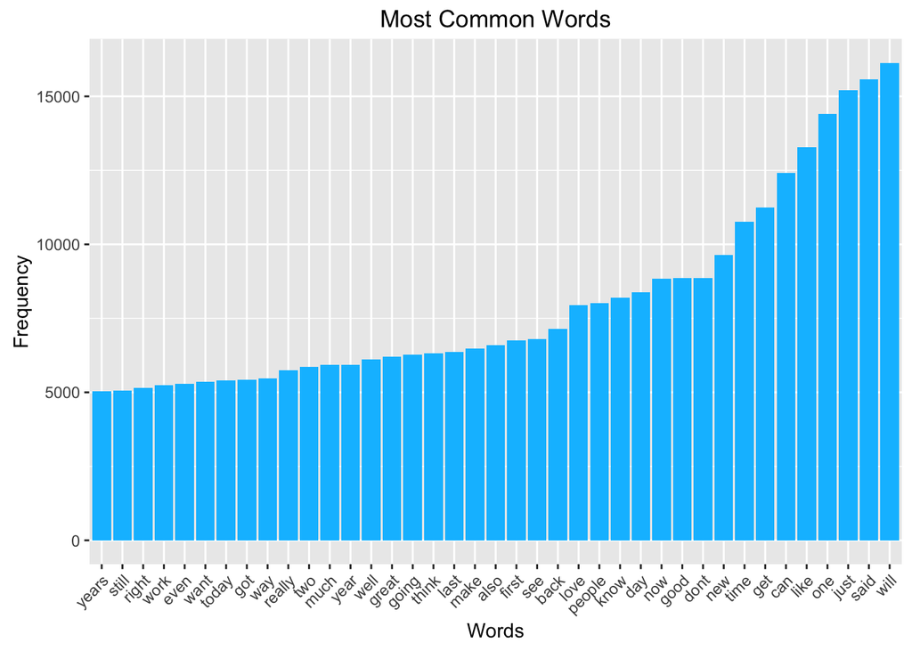

```r
minFreqUnigrams = 5000
wf <- data.frame(word=names(freq), freq=freq)

p <- ggplot(subset(wf, freq>minFreqUnigrams), aes(reorder(word, freq), freq))
p <- p + geom_bar(stat="identity", fill="deepskyblue")
p <- p + labs(title="Most Common Words", x="Words", y="Frequency")
p <- p + theme(axis.text.x=element_text(angle=45, hjust=1))
p
```

We conclude the analyses of single word frequencies plotting a word cloud with the most common terms, assigning different colors and size based on the frequency of the word

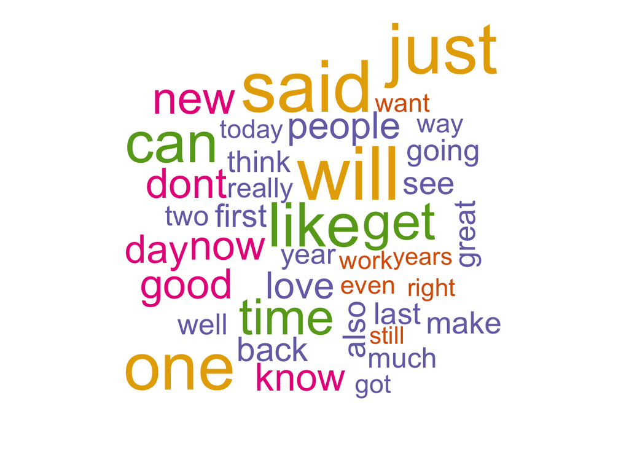

```r
wordcloud(names(freq), freq, min.freq=5000, scale=c(5, .1), max.words=50, colors=brewer.pal(6, "Dark2"))
```

## Analyze 2-grams and 3-grams frequencies

We preform the same analysis for bigrams and trigrams: we’d like to know which of them appear the most in the corpus.

```r
minFreqBigram <- 500
minFreqTrigram <- 50
freqBi <- col_sums(dtm_bigram)
freqTri <- col_sums(dtm_trigram)
ordBi <- order(freqBi)
ordTri <- order(freqTri)
freqBi[tail(ordBi, 10)]
```

```
##  first time high school   years ago    im going  last night   cant wait
##         636         679         702         735         760         942
##    new york   dont know   last year   right now
##         968         995        1001        1345
```

```r
freqTri[tail(ordTri, 10)]
```

```
##         new york times          cinco de mayo         happy new year
##                     63                     69                     70
## president barack obama          two years ago         im pretty sure
##                     73                     92                     99
##            let us know          new york city      happy mothers day
##                    121                    138                    173
##          cant wait see
##                    181
```

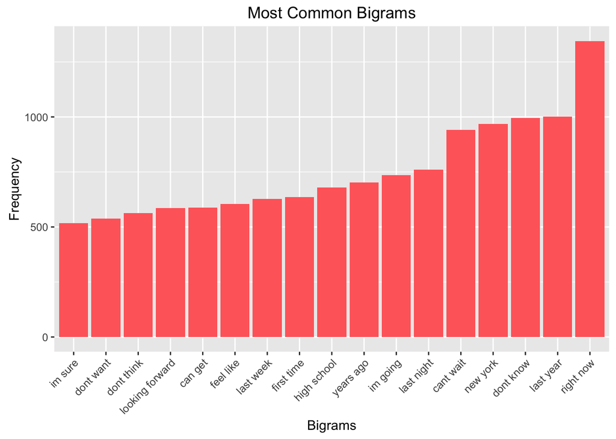

```r
bf <- data.frame(bigrams=names(freqBi), freq=freqBi)
tf <- data.frame(trigrams=names(freqTri), freq=freqTri)

p <- ggplot(subset(bf, freq>minFreqBigram), aes(reorder(bigrams, freq), freq))
p <- p + geom_bar(stat="identity", fill="indianred1")
p <- p + labs(title="Most Common Bigrams", x="Bigrams", y="Frequency")
p <- p + theme(axis.text.x=element_text(angle=45, hjust=1))
p
```

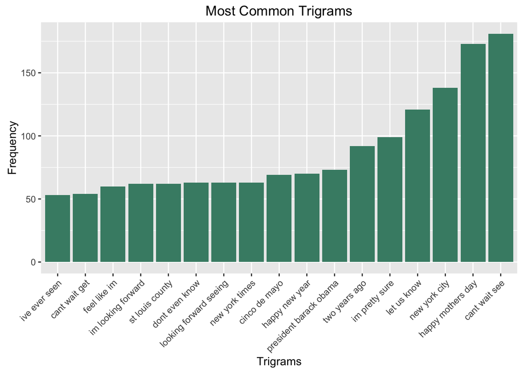

```r
p <- ggplot(subset(tf, freq>minFreqTrigram), aes(reorder(trigrams, freq), freq))
p <- p + geom_bar(stat="identity", fill="aquamarine4" )
p <- p + labs(title="Most Common Trigrams", x="Trigrams", y="Frequency")
p <- p + theme(axis.text.x=element_text(angle=45, hjust=1))
p
```